# Data Visualization with ggplot2

First a title and some axis labels. These are part of `labs()`.

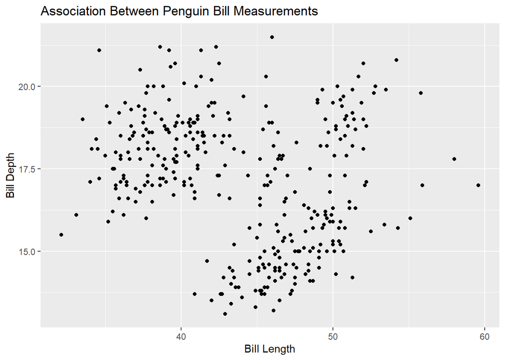

```r
#Getting fancy to show italics and greek symbols
penguin_gg <- ggplot(penguins, aes(bill_length_mm, bill_depth_mm)) +
  geom_point() +
  labs(title="Association Between Penguin Bill Measurements",
                     x="Bill Length", y="Bill Depth")
penguin_gg
```

Now to add some colors, shapes etc to the point. Look at the `geom_point()` documentation for this.

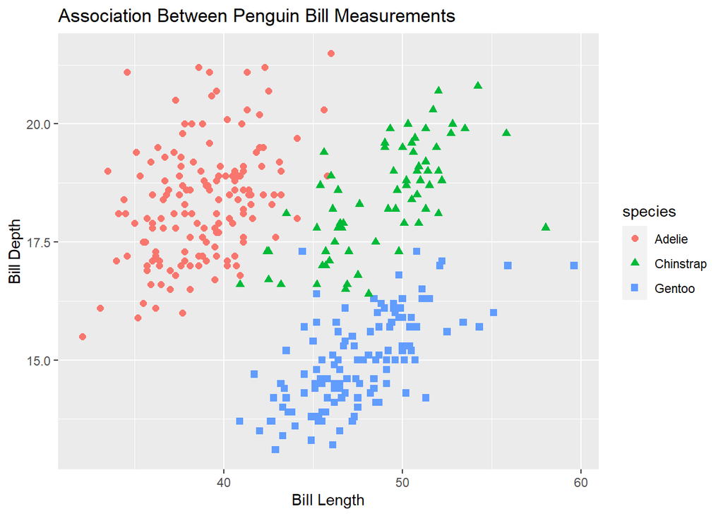

```r
penguin_gg <- ggplot(penguins, aes(bill_length_mm, bill_depth_mm)) +
  geom_point(aes(color=species, shape=species),size=2) +
  labs(title="Association Between Penguin Bill Measurements",
                     x="Bill Length", y="Bill Depth")
penguin_gg
```

You’ll notice we used `aes()` again, but this time inside of the geometry. This tells ggplot2 that this aes only applies to the points. Other geometries will not be affected by this.

In short, this is much easier than using base. Now `ggplot2` really shines when you want to add stats (regression lines, intervals, etc.).

Lets add a loess (LOcal RegrESSion) line with 95% confidence intervals.

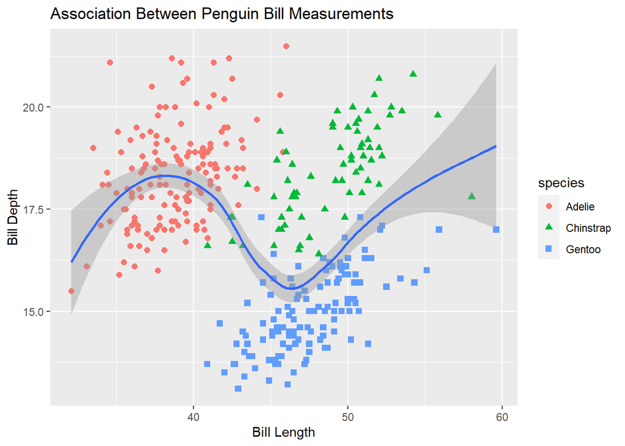

```r
penguin_scatter_loess <- ggplot(penguins, aes(bill_length_mm, bill_depth_mm)) +
  geom_point(aes(color=species, shape=species),size=2) +
  labs(title="Association Between Penguin Bill Measurements",
                     x="Bill Length", y="Bill Depth") +
  geom_smooth(method = "loess")
penguin_scatter_loess
```

Try that in `base` with so little code! But that doesn’t look quite right, so let’s try to add a linear regression line with:

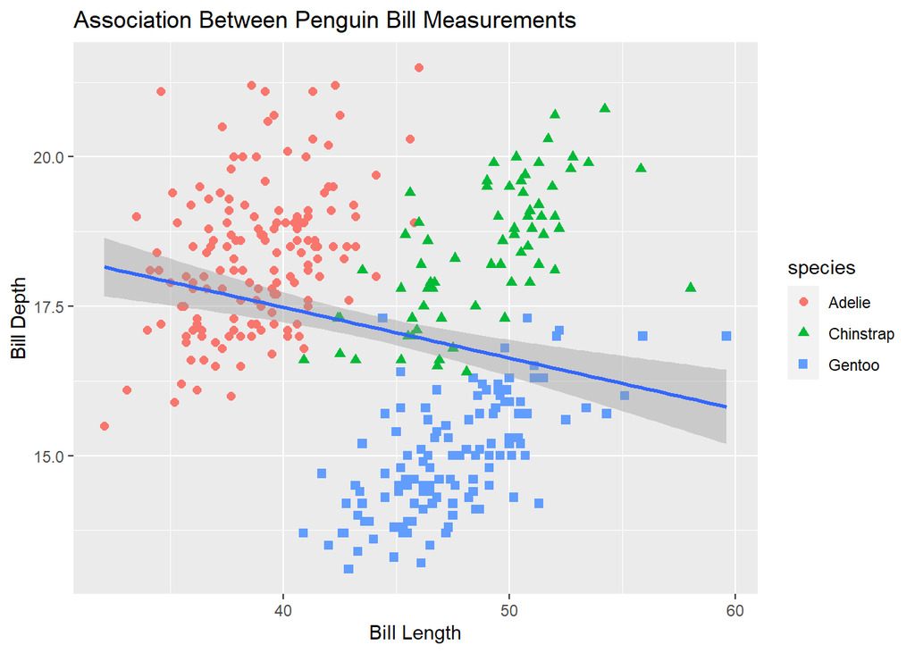

```r
penguin_scatter_lm <- ggplot(penguins, aes(bill_length_mm, bill_depth_mm)) +
  geom_point(aes(color=species, shape=species),size=2) +
  labs(title="Association Between Penguin Bill Measurements",
                     x="Bill Length", y="Bill Depth") +
  geom_smooth(method="lm")
penguin_scatter_lm
```

And that’s interesting… Maybe we shouldn’t pool these all together (read up on [Simpson’s Paradox](https://en.wikipedia.org/wiki/Simpson%27s_paradox)).

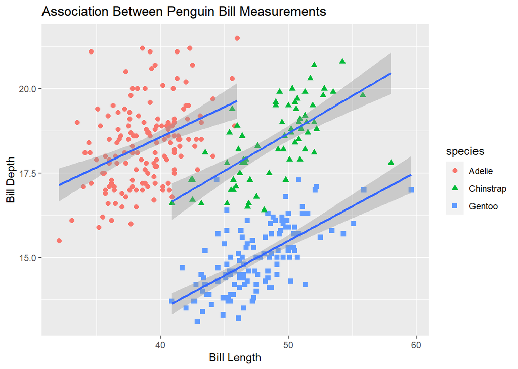

```r
penguin_scatter_lm_group <- ggplot(penguins, aes(bill_length_mm, bill_depth_mm)) +
  geom_point(aes(color=species, shape=species),size=2) +
  labs(title="Association Between Penguin Bill Measurements",
                     x="Bill Length", y="Bill Depth") +
  geom_smooth(method="lm", aes(group=species))
penguin_scatter_lm_group
```

And, if we wanted our regression lines to match the color.

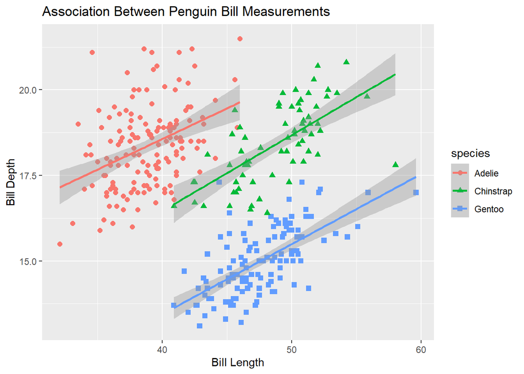

```r
penguin_scatter_lm_color <- ggplot(penguins, aes(bill_length_mm, bill_depth_mm)) +
  geom_point(aes(color=species, shape=species),size=2) +
  labs(title="Association Between Penguin Bill Measurements",
                     x="Bill Length", y="Bill Depth") +
  geom_smooth(method="lm", aes(color=species))
penguin_scatter_lm_color
```

Notice, that we specified the `aes()` again, but for `geom_smooth()`. We only specified the x and y in the original `ggplot` object, so if want to do something different in the subsequent functions we need to overwrite it for the function in which we want a different mapping (i.e. groups).

Now, I don’t particular love the default look and feel (e.g. background, plot boundaries, fonts, …) of these plots. We can control all of the with the use of `theme()`. Digging into the details on that is a bit beyond what we want to do now. That being said there are some other canned themes we can use

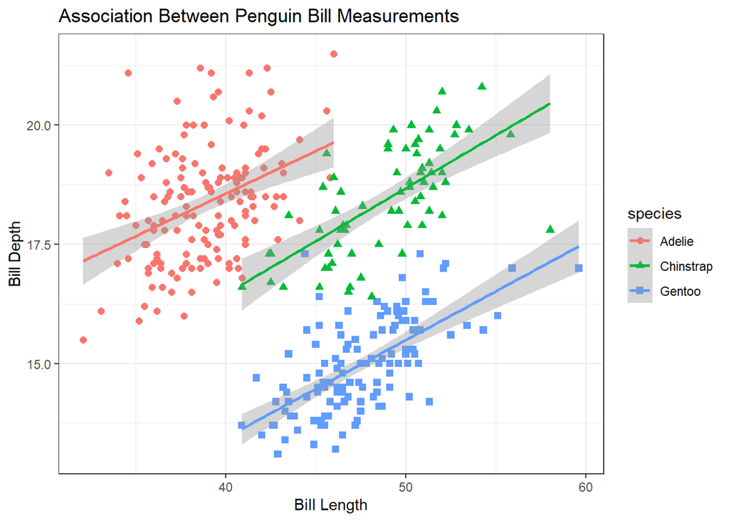

```r
# Black and white
penguin_scatter_lm_color + theme_bw()
```

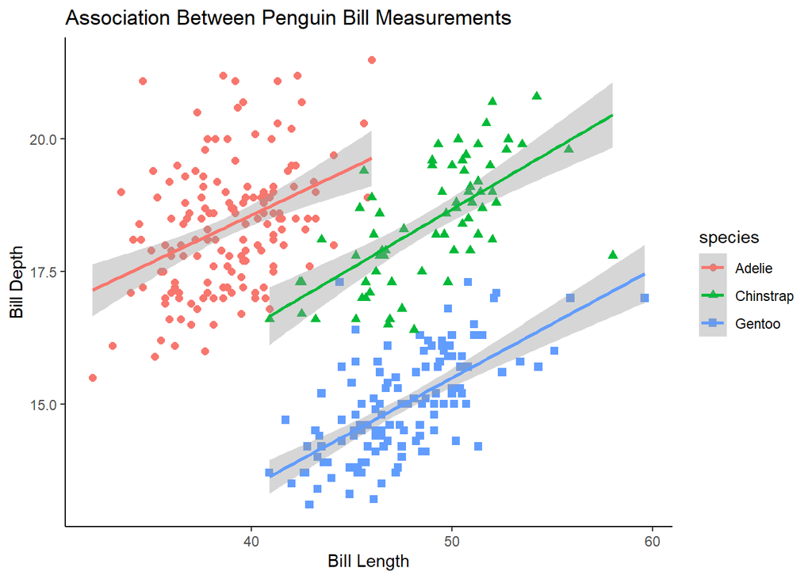

```r
# Classic
penguin_scatter_lm_color + theme_classic()
```

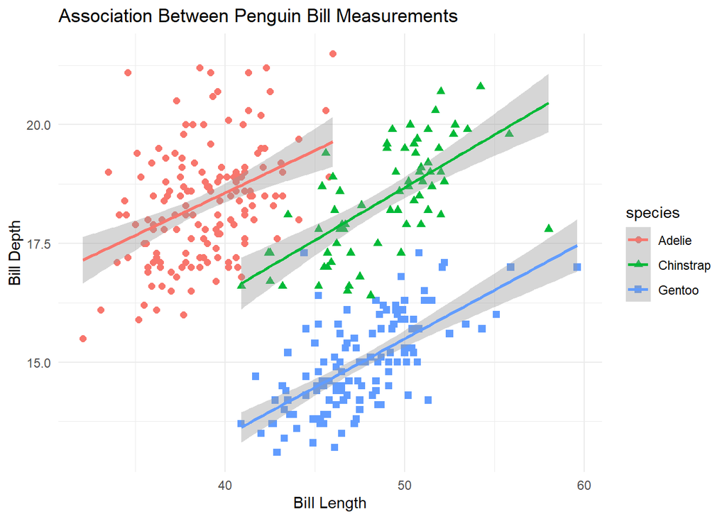

```r
# Minimal
penguin_scatter_lm_color + theme_minimal()
```

And if you want a whole lot more canned themes to play with, install and load the `ggthemes` package. And I’ll put in a plug here for the `hrbrthemes` from Bob Rudis. My go to is his `theme_ipsum_rc()`.

The above material is A LOT!! In short, we’ve seen that some of the initial setup for ggplot is a bit more verbose than base R, but when we want to do some more complex plots it is much easier in `ggplot2`.

Lastly, we have only looked at one geometry, but there are tons. Lets look at some of those. The best place to do this is excellent `ggplot2` documentation of the [geom functions](http://docs.ggplot2.org/current/).

## Punchline Example Explained

Now that we have the basics of `ggplot2` down, let’s take a closer look at our example in `acesd_analysis.R`.

## Homework 4.1

For this homework we will work on creating a new plot from scratch. Add some new code at the end of our `acesd_anlaysis.R` that does the following

1. Data visualization is as much data manipulation as it is figuring how to create a plot. We have already taken care of that with our prior homework. Lets use the `nla_wq_sites` data frame to create a new plot.
2. Let’s create a scatterplot with total nitrogen (`ntl`) on the x-axis, total phosphorus (`ptl`) on the y-axis, and color the points based on the `state`.
3. Set the size of all points to 5.
4. Use a theme other than the default.
5. And label your axes with good labels and add a meaningful title.
6. Try to use `ggplotly` from the `plotly` package to create an interactive version of this plot.
7. Don’t forget to comment your code.

As always, I am available to help if needed, just send me an email!